# Lecture Note: Geometric Brownian Motion

## BUFN400---University of Maryland

$\require{\newcommand}$ $\require{\renewcommand}$ $\newcommand{\E}{\mathrm{E}}$ $\newcommand{\e}{\mathrm{e}}$ $\newcommand{\drm}{\mathrm{\, d}}$ $\newcommand{\var}{\mathrm{var}}$ $\newcommand{\stdev}{\mathrm{stdev}}$ $\newcommand{\sm}{ {\scriptstyle{\text{*}}}}$ $\renewcommand{\mm}{{\scriptsize @}}$ $\renewcommand{\t}{^{\mathsf{T}}}$ $\renewcommand{\comma}{\, , \,}$ $\renewcommand{\vec}[1]{\mathbf{#1}}$

```python
import os
GLOBAL_NUM_THREADS = "1"
os.environ["OMP_NUM_THREADS"] = GLOBAL_NUM_THREADS
os.environ["OPENBLAS_NUM_THREADS"] = GLOBAL_NUM_THREADS
os.environ["MKL_NUM_THREADS"] = GLOBAL_NUM_THREADS
os.environ["VECLIB_MAXIMUM_THREADS"] = GLOBAL_NUM_THREADS
#os.environ["NUMEXPR_MAX_THREADS"] = GLOBAL_NUM_THREADS
os.environ["NUMEXPR_NUM_THREADS"] = GLOBAL_NUM_THREADS
os.environ["NUMBA_NUM_THREADS"] = GLOBAL_NUM_THREADS

import pandas as pd
import numpy as np
import scipy
#import scipy.sparse.linalg
import matplotlib
import matplotlib.pyplot as plt

import nbconvert
import sys
import datetime
import math
import string
import time
import timeit
import io
from pprint import pprint
#import numba
#import numexpr

import dataclasses

pd.set_option('display.max_rows', 500)
pd.set_option('display.max_columns', 50)
pd.set_option('display.width', 100)
pd.options.display.float_format = '{:,.4f}'.format

print('Python version ' + sys.version)
print('Pandas version ' + pd.__version__)
print('NumPy version ' + np.__version__)
print('SciPy version ' + scipy.__version__)
print('matplotlib version ' + matplotlib.__version__)
#print('numba version ' + numba.__version__)

timestamp = datetime.datetime.now().strftime('%Y-%m%d-%H%M')
print("Timestamp:", timestamp)
```

```
Python version 3.8.11 (default, Aug  6 2021, 09:57:55) [MSC v.1916 64 bit (AMD64)]
Pandas version 1.5.3
NumPy version 1.23.5
SciPy version 1.10.1
matplotlib version 3.7.1
Timestamp: 2023-1004-1343
```

# Introduction

Finance researcher often model stock prices, foreign currency prices, bonds, and other financial assets using **geometric Brownian motion**. Like yield to maturity and Gordon's growth model, the use of geometric Brownian motion to model stock returns is an approximation. Although not a perfectly accurate representation of the underlying **stochastic processes** which asset prices follow, geometric Brownian motion is close enough to generate useful intuition. Geometric Brownian motion is important for understanding the Black-Scholes model for option prices.

To understand geometric Brownian motion, it is first necessary to understanding Brownian motion. To understand Brownian motion, it is first necessary to understand normally distributed random variables.

Brownian motion has been used historically in many fields to describe or model random processes. Robert Brown described the random movement of grains of pollen as what we now call Brownian motion. Louis Bachelier used Brownian motion to describe stock prices. Albert Einstein applied Brownian motion to the study of physics. Norbert Weiner studied Brownian motion from the perspective of pure mathematics. **Brownian motion** is named after Robert Brown. **Wiener process** is another name for Brownian motion.

# Normal Distributions

A **standardized normal distribution** has a **probability density function** given by

$$ f(z) = \frac{1}{\sqrt{2\cdot \pi}} \cdot \mathrm{e}^{-z^2 / 2}. $$

The factor $\frac{1}{\sqrt{2\cdot \pi}}$ scales the density so that it integrates to one.

If $Z$ is a random variable with a **standard normal distribution**, the rescaled random variable $\mu + \sigma \cdot Z$ is a normally distributed random variable with mean $\mu$ and variance $\sigma^2$, which we denote $\mathcal{N}(\mu \; , \; \sigma^2)$. It has density

$$ f(z) = \frac{1}{\sigma \cdot \sqrt{2\cdot \pi}} \cdot \mathrm{e}^{-(z - \mu) ^2 / (2 \cdot \sigma^2)}. $$

A normal distribution is characterized by the two parameters $\mu$ and $\sigma$, measuring mean and variance.

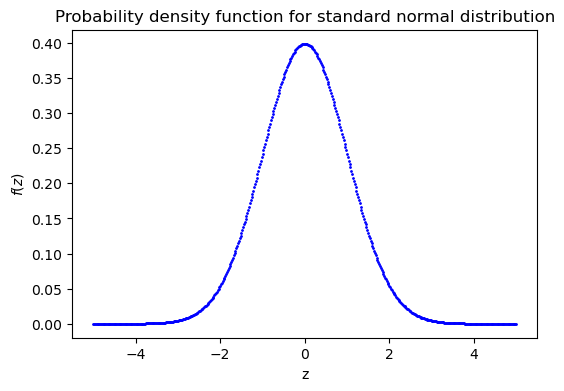

```python
nobs = 501
x = np.linspace(-5.00, 5.00, nobs)
fx = (1.00 / np.sqrt(2.00 * np.pi)) * np.exp(-0.50 * x * x)

fig = plt.figure(figsize=(6,4))
plt.plot(x, fx, 'bo', markersize=1.00)
plt.title("Probability density function for standard normal distribution")
plt.xlabel("z")
plt.ylabel("$f(z)$")
#plt.yscale('log')
plt.show()
```

From a finance perspective, an important property of normally distributed random variables is that **linear combinations** of **jointly normally distributed** random variables are themselves jointly normally distributed. For our purposes, if the vector of random variables $\mathbf{x} = (x_1, x_2, ... , x_N)$ are jointly normally distributed, then there exists a vector of means $\pmb{\mu} = (\mu_1, .., \mu_N)$, an $N \times N$ matrix $\mathbf{B}$, and a vector of independently distributed standard normal random variables $\mathbf{Z} = (Z_1, Z_2, ... , Z_N)$ such that $\mathbf{x} = \pmb{\mu} + \mathbf{B} \, \mathbf{Z}$. The random variables $\mathbf{Z}$ have $N \times N$ covariance matrix $\mathbf{B} \, \mathbf{B} ^ \mathsf{T}$.

# Central Limit Theorem

The normal distribution is related to the **central limit theorem**. There are many versions of the central limit theorem based on stronger or weaker assumptions. One version says that if $Z_1, Z_2, ...$ is a sequence of independently distributed random variables with zero mean and the same finite variance $\sigma^2$, then the sequence of weighted finite sums

$$ \frac{\sum_{n=1}^N Z_n}{\sigma \cdot \sqrt{N}} $$

converges **in distribution** (intuitively, in shape) to a **standardized normal distribution**, which is defined as a normal distribution with mean of zero and variance of one. The square root of $N$ in the denominator of the previous equation is important for understanding finance applications.

### Comment on computation

From a finance perspective, calculating the probability distribution function of a standard normal distribution,

$$ F(t) := \int_{z = -\infty}^{t} \; \frac{1}{\sqrt{2\cdot \pi}} \cdot \mathrm{e}^{-z^2 / 2} \mathrm{d}z, $$

often comes up in practice.

The Python package Scipy has functions for this.

Computational advice: If $t$ is large, then $F(t)$ is slightly less than one. If you really want $1 - F(t)$, there can be a problem with rounding error. This can be dealt with either by taking advantage of the symmetry of the normal distribution or by using the scipy functions *sf* and *logsf*, where "sf" means "survival function," which is defined as $1 - F(t)$ (the right tail of the distribution). Here is an example where rounding error makes $1 - F(t)$ zero when it should be a small positive number:

```python
# see https://stackoverflow.com/questions/50282805/evaluate-log1-normal-cdfx-in-a-numerically-stable-way

import scipy
import scipy.stats

t = 10.00

y1 = 1.00 - scipy.stats.norm.cdf(t)  # numerically equal to zero: might be a problem!
y2 = scipy.stats.norm.cdf(-t)  # use symmetry of normal distribution about zero
y3 = scipy.stats.norm.sf(t) # use survival function

print(f"The following are theoretically the same: {y1=}, {y2=}, {y3=}")
```

```
The following are theoretically the same: y1=0.0, y2=7.61985302416047e-24, y3=7.61985302416047e-24
```

# Brownian motion

A Brownian motion process is a continuous-time stochastic process, which is typically denoted $B(t)$ (for "Brownian") or $W(t)$ (for "Weiner"). A Brownian motion proces is defined by two important properties:

1. The **increments** to the process $B(t + \Delta t) - B(t)$ are **normally distributed** with zero mean and variance $\sigma^2 \cdot \Delta t$. The **instantaneous variance** $\sigma^2$ is a constant in the sense that it does not vary as a function of $t$.
2. The increments to the process $B(t + \Delta t) - B(t)$ are **independently distributed** from the history of the process up to date $t$. This, of course, implies that increments over non-overlapping intervals of time are independently distributed and therefore **uncorrelated**.

Brownian motion is often assumed to satisfy the property $B(0) = 0$. For finance applications, we often choose $B(0)$ to be a non-zero value consistent with an initial asset price (often the log of the asset price). A **Brownian motion with drift** is a Brownian motion in which the zero mean assumption is replaced by the assumption that the increments $B(t + \Delta t) - B(t)$ have mean $\mu \cdot \Delta t$, where $\mu$ is a constant which does not depend on $t$. In finance applications, the drift is related to the expected return (but it is not exactly the expected return, as we discuss below).

Brownian motion has some other interesting properties. Each realization of a Brownian motion process, called a **sample path**, is a function of the continuous variable $t$ (for "time"). The sample paths are **continuous functions of time** (with probability one); this means the sample paths have no jumps. The Brownian motion sample path can be approximated as a discrete-time process sampled, for example, at equally spaced intervals which are close together. Each sample path has **infinite absolute variation** in the sense that

$$ \lim \sum_{n=0}^N \lvert B(T \cdot n / N) - B(T \cdot (n-1) / N) \rvert \rightarrow \infty \qquad \text{as} \qquad N \rightarrow \infty, $$

even though the **quadratic variation** is finite in the sense that

$$ \lim \sum_{n=0}^N \bigl (B(T \cdot n / N) - B(T \cdot (n-1) / N) \bigr)^2 \rightarrow \sigma^2 \cdot T \qquad \text{as} \qquad N \rightarrow \infty, $$

where convergence to $T$ is **convergence in probability** (intuitively, the result becomes arbitrarily close to $T$ with high probability).

Intuitively, **infinite variation** means that the point of a pencil would have to travel an infinite amount of distance (on a piece of paper) to draw the graph of a Brownian motion sample path over any finite interval, even a small one.

Intuitively, Brownian motion is consistent with the central limit theorem because we can express the increment over a large time interval $T$, given by $B(t + T) - B(t)$, as the sum of independent increments over many small intervals, $\sum_{n=1}^N B(t + n \cdot T / N) - B(t + (n-1) \cdot T / N)$.

# Exercise for self-study

It can be shown that if $B(t)$ is a standard Brownian motion, then

$$ \mathrm{E} \left[ \left| B(t + \Delta t) - B(t) \right| \right] = \sqrt{\frac{2 \cdot \Delta t}{ \pi}}. $$

Use this fact to prove (informally) that a Brownian motion sample path has infinite variation.

It is easy to use the Python package Numpy to model the sample paths of a Brownian motion by sampling at regularly spaced intervals.

Here is an example in which we model the daily stock price as Brownian motion with initial value of 100 dollars per share and a daily standard deviation of 2 dollars per day:

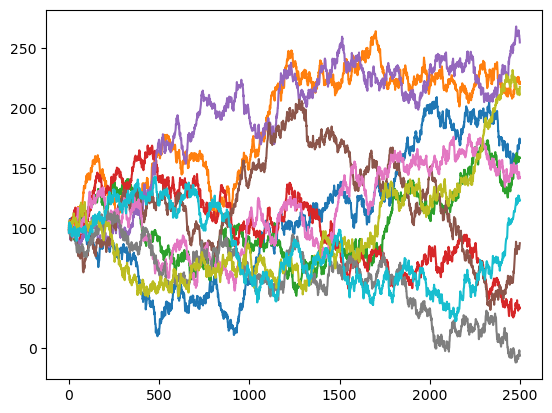

```python
import numpy as np
import matplotlib.pyplot as plt

n = 2500
m = 10

p0 = 100.00
sigma = 2.00

rng = np.random.default_rng(seed=12345)
dz = rng.standard_normal(n * m).reshape(n, m)
z = p0 + sigma * dz.cumsum(axis=0)

plt.plot(z)
plt.show()
```

# Is Brownian motion a bad model for stock prices?

Suppose $P(t)$ is a Brownian motion meant to model a stock price. The Brownian motion model has some major obvious shortcomings:

1. A Brownian motion process can attain a negative value. We often think of stock prices as having **limited liability**, which implies the stock price should never fall below zero, at least in theory. In a model, we would probably not want $P(t)$ to ever be negative.
2. The volatility of a stock price is constant in dollar terms. Suppose the standard deviation is such that a one-standard deviation price changes is 2 dollars per day. If $P(t) = 100$ dollars per share, then the daily standard deviation of 2 dollars per day might be empirically reasonable because 2.00 percent daily standard deviation is empiricall reasonable. If the price falls to 10 dollars, then the daily percentage standard deviation rises to 20 percent, which might be unreasonably large (and makes it easy for the stock price to become negative).

Geometric Brownian motion deals with both of these problems.

# Geometric Brownian motion

If $p(t)$ is a Brownian motion, then $P(t) := \mathrm{e}^{p(t)}$ defines a **geometric Brownian motion** process. Exponentiation of a Brownian motion results in geometric Brownian motion. Taking the log of geometric Brownian motion results in Brownian motion.

Modeling stock prices as geometric Brownian has the advantages Brownian motion lacks:

1. The sample paths always remain strictly positive, although the paths can make the price very close to zero. This is because $\exp(p)$ is always positive.
2. Both the **log-volatility**, defined as the standard deviation of $\log\bigl( \frac{P(t + \Delta t)}{P(t)} \bigr)$, and the percentage volatility, defined as the standard deviation of $\frac{P(t + \Delta t) - P(t)}{P(t)}$, are constants which do not depend on $t$ or $P(t)$.

In the field of finance, both researchers and practitioners have developed ways of mapping the mean and variance of the underlying Brownian motion into the mean and variance of the returns on the stock modeled as geometric Brownian motion. This mapping is not completely straightforward and is therefore a frequent source of errors and confusion.

Suppose the underlying Brownian motion has mean (drift) $\mu$ and instantaneous variance $\sigma^2$.

# Volatility of geometric brownian motion

The log-volatility and percentage volatility are given by

$$ \text{log volatility} = \mathrm{std} \left[ \log\bigl( \frac{P(t + \Delta t)}{P(t)} \bigr) \mid \mathcal{H}(t) \right] = \sigma \cdot \sqrt{\Delta t}, $$$$ \text{percentage volatility} = \mathrm{std} \left[ \frac{P(t + \Delta t) - P(t)}{P(t)} \mid \mathcal{H}(t) \right] = \mathrm{e}^{\mu \cdot \Delta t} \cdot \sqrt{\mathrm{e}^{\sigma^2 \cdot \Delta t} - 1}. $$

For small values of $\mu$ and $\Delta t$, the log volatility and the percentage volatility are almost the same. In particular, when working with daily data on stock prices, it usually does not matter whether log-volatility or percentage volatility is used. Empirical researchers calculate volatility both ways. Over long time periods, say yearly observations, empirical researchers also calculate volatility both ways, even though log-volatility might be preferred.

A particularly attractive property of log-volatility is that it can be calculated exactly without knowledge of the mean $\mu$. For this reason, log volatility is used when the mean is unknown. In both theoretical and empirical work, the terms **volatility** means $\sigma$. The parameter $\sigma$ is often called **Black-Scholes volatility** because it means the same thing as the volatility parameter $\sigma$ which shows up in the Black-Scholes formula, which does not use the mean $\mu$ and therefore effectively assumes the mean is unknown.

The factor $\sqrt{\Delta t}$, which shows up in the formula for log-volatility, is important. For example, if a stock has a "typical" daily volatility of 2.00 percent, the annual volatility is $2.00 \cdot \sqrt{D}$, where $D$ is the number of trading days in the year. For mental calculations is it convenient to pretend that there are about 256 trading days per year. Since $\sqrt{256} = 16$, this would imply an annual volatility of 32.00 percent. In fact, the number of trading days per year might be closer to 250 due to holidays.

### Optional: A note on time units

Taking the square root of variance to obtain standard deviation (volatility) affects the units in which volatility is measured. Technically, a Brownian motion process has no units; neither does a geometric Brownian motion process. This must be the case since both $P(t)$ and $p(t)$ in the formula $P(t) = \mathrm{e}^{p(t)}$ must be dimensionless. In the formula for percentage volatility we see $\mathrm{e}^{\sigma^2 \cdot \Delta t}$; the $\sigma^2 \cdot \Delta t$ must also be dimensionless, consistent with the variance of the increment of a dimensionless process being dimensionless. Since $\Delta t$ has units related to time (days, years), the parameter $\sigma^2$ is measured per day or per year, like an interest rate. This implies that volatility has seemingly unusual units "per square root of a day" or $1 / \sqrt{\text{day}}$. These seemingly unusual units are exactly what is needed to be consistent with $\sqrt{\Delta t}$ showing up in the formula for log-volatility!

In modeling, we often start with a **standardized Brownian motion** with mean $\mu = 0$ and variance $\sigma^2 = 1$ per year or per day, depending on how the time parameter is measured. We then change the variance to some other value $\sigma^2 \ne 1$ by multiplying the process by a volatility parameter $\sigma$. More precisely, we should think of this parameter as dimensionless, as either a ratio of volatilities or as something like $\sigma \cdot \sqrt{\text{1 day}}$, to make it dimensionless.

Conclusion: Finance researchers and practitioners are often sloppy when keeping track of units, especially related to time. Nevertheless, understanding the logic for these units can avoid errors and aid in understanding concepts.

### Percentage volatility and log-volatility

Using properties of the $\log$ function, it is tempting to write $\log\bigl( \frac{P(t + \Delta t)}{P(t)} \bigr) = \log P(t + \Delta t) - \log P(t)$. Strictly speaking, the right side is not correct since $P(t + \Delta t)$ and $P(t)$ must be dimensionless, but instead both $P(t + \Delta t)$ and $P(t)$ have units of dollars per share. To make the right side correct, it is---strictly speaking---necessary to scale both prices by $1 \text{USD} / \text{share}$ and write

$$ \log\bigl( \frac{P(t + \Delta t)}{P(t)} \bigr) = \log\bigl( \frac{P(t + \Delta t)}{1 \text{USD} / \text{share}} \bigr) - \log\bigl( \frac{P(t + \Delta t)}{1 \text{USD} / \text{share}} \bigr). $$

In practice, this scaling does not really matter.

# Convexity and Jensen's inequality

A function $f(x)$ is **convex** on an interval $[A,B]$ if

$$ \alpha \cdot f(x_0) + (1 - \alpha) \cdot f(x_1) \ge f \bigl( \alpha \cdot x_0 + (1-\alpha) \cdot x_1 \bigr) \qquad \text{for all} \qquad A \le x_0 < x_1 \le B, \quad 0 \le \alpha \le 1. $$

In other words, a line segment connecting two points on the graph of the function lies on or above the graph of the function.

**Jensen's inequality**, which is closely related to the definition of convexity, states that if $f(x)$ is a convex function and $x$ is a random variable, then

$$ \mathrm{E} [f(x)] \ge f(\mathrm{E}[x]). $$

A function $g(x)$ is **concave** if $-g(x)$ is convex.

Convexity and concavity are important in many finance applications:

1. The concept of convexity is used extensively in option pricing.
2. Concave functions are used to model risk aversion on the part of investors and therefore to quantify by how much the expected return on risky assets exceeds the expected return on safe assets.
3. The $\log$ function, which is concave, and $\exp$ function, which is convex, show up frequently in finance.

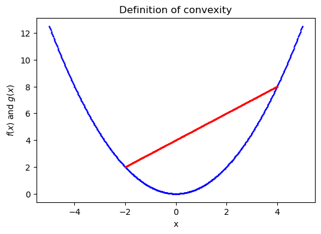

```python
# Arbitrary convex function:
def f(x):
    return 0.50 * x * x

# Linear function whose graph connects two points on the graph of f(x):
def g(y, y0, y1):
    g0 = f(y0)
    g1 = f(y1)
    return g0 + ((y - y0) / (y1 - y0)) * (g1 - g0)

nobs = 501
x0 = -5.00
x1 = 5.00
x = np.linspace(x0, x1, nobs)
fx = f(x)

y0 = -2.00
y1 = 4.00
y = np.linspace(y0, y1, nobs)
gy = g(y, y0, y1)

fig = plt.figure(figsize=(6,4))
plt.plot(x, fx, 'bo', markersize=1.00)
plt.plot(y, gy, 'ro', markersize=1.00)
plt.title("Definition of convexity")
plt.xlabel("x")
plt.ylabel("$f(x)$ and $g(x)$")
#plt.yscale('log')
plt.show()
```

# Mean of geometric Brownian motion

Measuring the mean of geometric Brownian motion raises issues relate to convexity.

When defining $P(t) = \mathrm{e}^{p(t)}$, notice that the $\exp$ function is **convex**. This makes $P(t)$ a convex function of $p(t)$ and makes $P(t + \Delta t) / P(t)$ a convex function of $p(t + \Delta t) - p(t)$ given by $\frac{P(t + \Delta t)}{P(t)} = \mathrm{e}^{p(t + \Delta t) - p(t)}$. Jensen's inequality says

$$ \mathrm{E} \left[ \frac{P(t + \Delta t)}{P(t)} \right] \ge \mathrm{e}^{\mathrm{E}[p(t + \Delta t) - p(t)]}. $$

If $p(t)$ is a Brownian motion with drift $\mu$ and variance $\sigma^2$, it can be shown that

$$ \mathrm{E} \left[ \frac{P(t + \Delta t)}{P(t)} \right] = \mathrm{e}^{(\mu + \sigma^2 / 2) \cdot \Delta t}. $$

The $\sigma^2$ term in the exponent is consistent with left side of the equation for Jensen's inequality. If this term were omitted, we would obtain the right side of Jensen's inequality by setting $\sigma^2 = 0$; this makes the right side less than the left side, consistent with Jensen's inequality and the convexity of the $\mathrm{exp}$ function.

Suppose we are modeling stock prices and want the continuously compounded expected return associated with investing in the stock with price $P(t)$ (no dividends, only capital gains) to be $\bar{r}$. This means we want

$$ \mathrm{E} \left[ \frac{P(t + \Delta t)}{P(t)} \right] = \mathrm{e}^{\bar{r} \cdot \Delta t}. $$

This implies that we should choose drift $\mu = \bar{r} - \tfrac{1}{2} \cdot \sigma^2$ when defining the underlying Brownian motion, which represents the log of the price.

Since the $\log$ function is concave, Jensen's inequality applies in reverse. If a stock following geometric Brownian motion has continuously compounded expected return $\bar{r}$, the expected log-return is

$$ \mathrm{E} \left[ \log \left( \frac{P(t + \Delta t)}{P(t)} \right) \right] = (\bar{r} - \tfrac{1}{2} \cdot \sigma^2) \cdot \Delta t, $$

not $\bar{r} \cdot \Delta t$.

The presence of the $\tfrac{1}{2} \cdot \sigma^2$ term in expectations related to the $\log$ and $\exp$ functions is a constant source of confusion and errors in finance applications, both by researchers and practitioners.

# A example of geometric Brownian motion

Suppose we want to simulate 10 sample paths of a stock price with daily volatility of 2.00 percent and continuously compounded expected return of 10.00 percent per year (so one dollar grows in expectation to $\mathrm{e}^{0.10 \cdot m}$ dollars in $m$ years), with an initial stock price of 100 dollars, 250 trading days per year, for 10 years.

This is straightforward to do using the Python package Numpy:

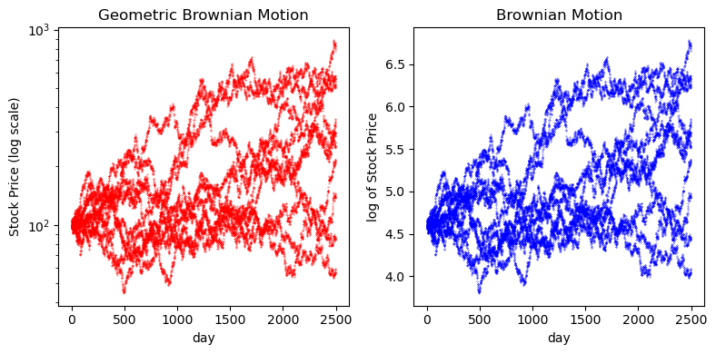

```
np.exp(rbar_per_year) - 1.00=0.10517091807564771
rmean_year=array([ 0.193192  ,  0.24436231,  0.17302862,  0.03446542,  0.28886832,
        0.09398726,  0.1548442 , -0.00796474,  0.24146702,  0.13600931])
dp_pct_std=array([0.02049635, 0.02014707, 0.01982738, 0.02006589, 0.01973004,
       0.02017327, 0.01991299, 0.01996315, 0.01983326, 0.02012401])
```

```python
import numpy as np
import matplotlib.pyplot as plt

number_of_years = 10
days_per_year = 250
m = 10  # number of stocks
rbar_per_year = 0.1000
p0 = 100.00
sigma = 0.0200 # daily volatility

n = number_of_years * days_per_year
rbar = rbar_per_year / days_per_year  # daily log-return for continuous compounding
#rbar = (1.00 + rbar_per_year)**(1.00 / days_per_year) - 1.00
#rbar = np.log1p(rbar_per_year) / days_per_year

mu = rbar - sigma * sigma * 0.50

rng = np.random.default_rng(seed=12345)
dz = rng.standard_normal(n * m).reshape(n, m)
P = p0 * np.exp((sigma * dz + mu).cumsum(axis=0))

# t = np.array(range(n))
t = np.full((n,), 1.00).cumsum() - 1.00  # more efficient than range(n)!

if n < 10000:

    fig, ax = plt.subplots(1, 2, figsize=(8, 4))

    ax[0].set_title("Geometric Brownian Motion")
    ax[0].set_xlabel("day" )
    ax[0].set_ylabel("Stock Price (log scale)")
    ax[0].plot(t, P, 'ro', markersize=0.25)
    ax[0].set_yscale('log', base=10)

    ax[1].set_title("Brownian Motion")
    ax[1].set_xlabel("day")
    ax[1].set_ylabel("log of Stock Price")
    ax[1].plot(t, np.log(P), 'bo', markersize=0.25)

    plt.tight_layout() # Prevents plots from being squashed together too much.

    plt.show()

dp_pct = (P[1:, :] - P[:-1, :]) / P[:-1, :]
rmean = dp_pct.mean(axis=0)
rmean_year = (1.00 + rmean)**days_per_year - 1.00

dp_pct_std = dp_pct.std(axis=0)

print(f"{np.exp(rbar_per_year) - 1.00=}")
print(f"{rmean_year=}")
print(f"{dp_pct_std=}")
```

Note that plotting the geometric Brownian motion on a log scale makes both plots have identical shapes.

# Problem for self-study

When working with simulated data, it is often a good idea to debug code by checking that correct outcomes are generated when you can calculate the theoretically correct results in you head.

1. In the example above, verify that the sample mean is close to the theoretical mean when the standard deviation is very small.
2. Verfiy that the percentage standard deviation is close to the log standard deviation *sigma*.
3. Change the problem so that data is generated monthly rather than daily, and the number of years is increased from 10 to 100.

NB: The example uses different time units for mean and standard deviation: annually for mean, daily for standard deviation. This is not a problem provided appropriate adjustments are made in the code itself.

# Risk Premium and Sharpe ratio

Suppose that a stock has an expected return (continuously compounded) of $\bar{r} = r_f + \pi$, where $r_f$ is the risk-free rate and $\pi$ is the **true (i.e. theoretical) risk premium**. In practice, we can think of the risk-free rate $r_f$ as being observed. The risk premium is not observed. Instead, researchers and traders try to estimate the true risk premium using models and data.

A better way to describe the risk-retrn tradeoff is to scale the risk premium by the standard deviation of returns. Finance researchers called this scaled return a **Sharpe ratio**, named after William Sharpe, one of the creators of the **Capital Asset Pricing Model.** The **true Sharpe ratio** or **theoretical Sharpe ratio** is defined as

$$ \text{Sharpe Ratio} = \frac{\bar{r} - r_f}{\sigma} = \frac{\pi}{\sigma}. $$

In practice, researchers often construct empirical proxies for the Sharpe ratio. One approach is to calculate a **historical average Sharpe ratio** over some period of time. Another approach is to use data to construct an **estimated Sharpe ratio**, which might use the historical average Sharpe ratio as inputs but might include other inputs as well.

# Demand for risky assets

The historical Sharpe ratio is often used in construcing demands for risky assets. Let $\alpha$ denote the fraction of a portfolio value invested in a risky asset and $1-\alpha$ the fraction invested in a safe asset earning the risk-free rate of interest. The demand function for the risky asset is often expressed as:

$$ \alpha = \rho \cdot \frac{\pi}{\sigma^2}. $$

where the parameter $\rho$ is a risk aversion coefficient. A typical value $\rho=1$ corresponds to what finance researchers call **logarithmic utility**.

The expected return on this portfolio is $r_f + \alpha \cdot \pi$, and the standard deviation of returns on the portfolio is approximately $\alpha \cdot \sigma$, which equals $\rho \cdot \frac{\pi}{\sigma}$. With log utillity ($\rho=1$), the volatility of the portfolio return is precisely the Sharpe ratio.

# Notes

1. Random Walk
2. Constant investment opportunity set.
3. Log utility
4. Growth-optimal portfolio
5. Bootstrapping